# Weather and Corn Yield Regressions

### Question 1b: Fit a quadratic time trend (i.e., year + year^2) and make a plot. Is there evidence for slowing yield growth?

```r
winniecorn$yearsq <- winniecorn$year^2

lm_cornyield <- lm(yield ~ year + yearsq, winniecorn)
summary(lm_cornyield)
```

```
##
## Call:
## lm(formula = yield ~ year + yearsq, data = winniecorn)
##
## Residuals:
##     Min      1Q  Median      3Q     Max
## -51.384  -3.115   1.388   9.743  25.324
##
## Coefficients:
##               Estimate Std. Error t value Pr(>|t|)
## (Intercept)  2.583e+04  8.580e+04   0.301    0.765
## year        -2.812e+01  8.576e+01  -0.328    0.745
## yearsq       7.641e-03  2.143e-02   0.357    0.723
##
## Residual standard error: 17.17 on 38 degrees of freedom
## Multiple R-squared:  0.7559, Adjusted R-squared:  0.7431
## F-statistic: 58.84 on 2 and 38 DF,  p-value: 2.311e-12
```

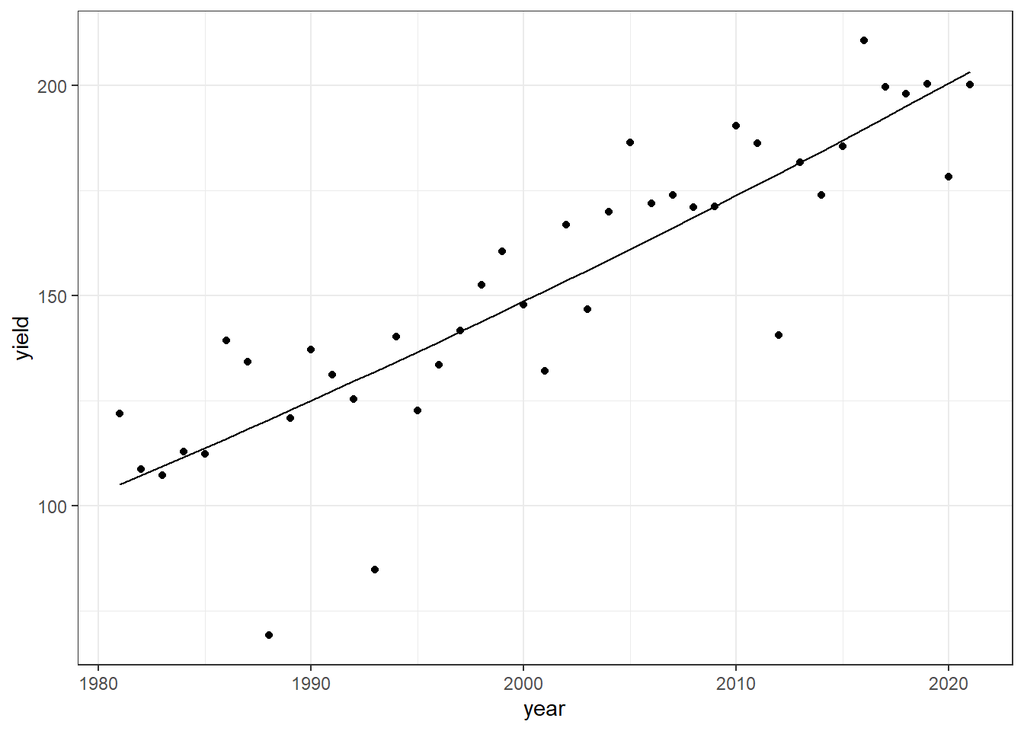

```r
winniecorn$fitted <- lm_cornyield$fitted.values

ggplot(winniecorn) +
  geom_point(mapping = aes(x = year, y = yield)) +
  geom_line(mapping = aes(x = year, y = fitted)) +
  theme_bw() +
  labs(x = "year", y = "yield")
```

There is not evidence for slowing yield growth.

### Question 2 – Time Series: Let’s analyze the relationship between temperature and yields for the Winneshiek County time series. Use data on yield and summer avg Tmax. Is adding year or Tmax^2 to your model helpful? Make a plot and interpret the results.

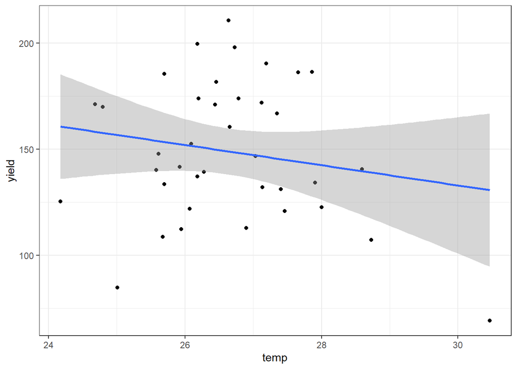

```r
winniecorn2 <- right_join(winniecorn, winnesummer, by = "year")

ggplot(winniecorn2, mapping = aes(x = meantmax, y = yield)) +
  geom_point() +
  theme_bw() +
  labs(x = "temp", y = "yield") +
  geom_smooth(method = lm)
```

```r
lm_q2 <- lm(yield ~ meantmax + year, data = winniecorn2)
summary(lm_q2)
```

```
##
## Call:
## lm(formula = yield ~ meantmax + year, data = winniecorn2)
##
## Residuals:
##     Min      1Q  Median      3Q     Max
## -53.071  -7.269   2.271   9.935  27.505
##
## Coefficients:
##              Estimate Std. Error t value Pr(>|t|)
## (Intercept) -4791.774    513.812  -9.326 5.10e-11 ***
## meantmax       -3.201      2.308  -1.387    0.174
## year            2.514      0.253   9.934 1.01e-11 ***
## ---
## Signif. codes:  0 '***' 0.001 '**' 0.01 '*' 0.05 '.' 0.1 ' ' 1
##
## Residual standard error: 17.06 on 35 degrees of freedom
## Multiple R-squared:  0.7463, Adjusted R-squared:  0.7318
## F-statistic: 51.48 on 2 and 35 DF,  p-value: 3.761e-11
```

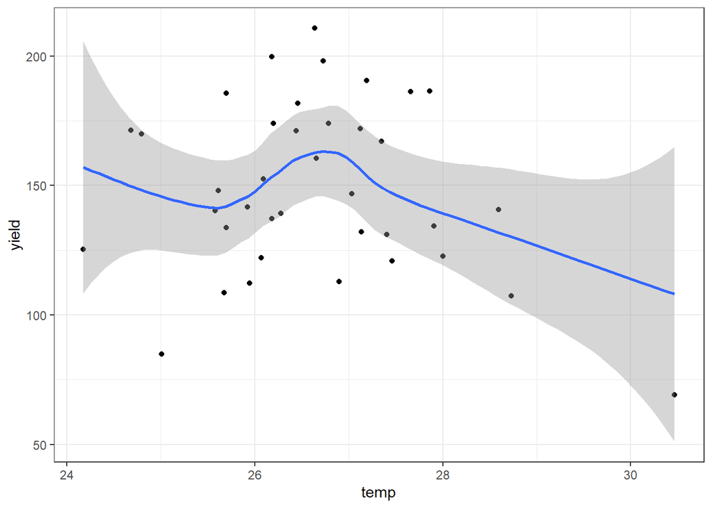

```r
winniecorn2$fitted <- lm_q2$fitted.values

ggplot(winniecorn2) +
  geom_point(mapping = aes(x = meantmax, y = yield)) +
  geom_smooth(mapping = aes(x = meantmax, y = fitted)) +
  theme_bw() +
  labs(x = "temp", y = "yield")
```

### Question 3 – Cross-Section: Analyze the relationship between temperature and yield across all counties in 2018. Is there a relationship? Interpret the results.

In 2018, there is a negative relationship (slope = -4.216) between temperature and yield across counties.

```r
cornyields$countyfp <- as.factor(cornyields$county_ansi)
cornyields2018 <- cornyields %>% filter(year== "2018")

q3 <- tmaxdf %>% filter(year == "2018" & doy >= 152 & doy <= 243) %>%
  group_by(countyfp) %>% summarize(meantmax = mean(tmax)) %>%
  left_join(cornyields2018, by = 'countyfp') %>% filter(!is.na(yield))

lm_2018 <- lm(yield ~ meantmax, data = q3)
summary(lm_2018)
```

```
##
## Call:
## lm(formula = yield ~ meantmax, data = q3)
##
## Residuals:
##     Min      1Q  Median      3Q     Max
## -42.983 -15.041   0.955  16.795  31.999
##
## Coefficients:
##             Estimate Std. Error t value Pr(>|t|)
## (Intercept)  312.466     63.387   4.929 3.69e-06 ***
## meantmax      -4.216      2.241  -1.882   0.0631 .
## ---
## Signif. codes:  0 '***' 0.001 '**' 0.01 '*' 0.05 '.' 0.1 ' ' 1
##
## Residual standard error: 19.64 on 91 degrees of freedom
## Multiple R-squared:  0.03745,    Adjusted R-squared:  0.02687
## F-statistic: 3.541 on 1 and 91 DF,  p-value: 0.06308
```

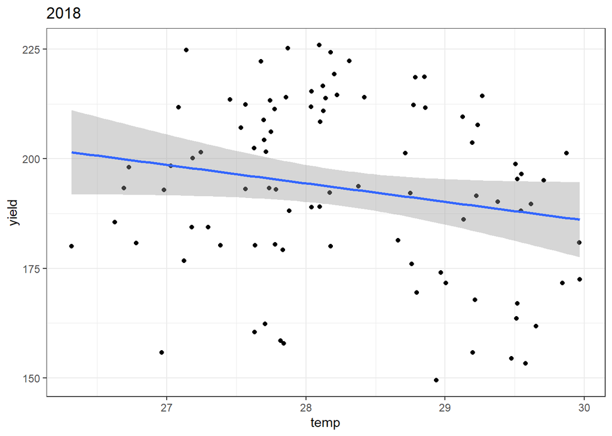

```r
ggplot(q3, aes(x = meantmax, y = yield)) +
  geom_point() +
  theme_bw() +
  geom_smooth(method = lm)+
  labs(x = "temp", y = "yield", title = "2018")
```

### Question 4 – Panel: One way to leverage multiple time series is to group all data into what is called a “panel” regression. Convert the county ID code (“countyfp” or “county_ansi”) into factor using as.factor, then include this variable in a regression using all counties’ yield and summer temperature data. How does the significance of your temperature coefficients (Tmax, Tmax^2) change? Make a plot comparing actual and fitted yields and interpret the results of your model.

In this model, year is the only significant predictor of yield (p < 2e-16).

```r
q4 <-  tmaxdf %>% filter( doy >= 152 & doy <= 243) %>%
  group_by(countyfp) %>% summarize(meantmax = mean(tmax)) %>%
  left_join(cornyields, by = 'countyfp') %>% filter(!is.na(yield)) %>%
  mutate(tmaxsq = (meantmax)^2)

lm_q4 <- lm(yield ~ meantmax + tmaxsq + year + countyfp, data = q4)
summary(lm_q4)
```

```
##
## Call:
## lm(formula = yield ~ meantmax + tmaxsq + year + countyfp, data = q4)
##
## Residuals:
##      Min       1Q   Median       3Q      Max
## -101.016   -9.576    3.141   14.498   52.720
##
## Coefficients: (2 not defined because of singularities)
##               Estimate Std. Error t value Pr(>|t|)
## (Intercept) -8.464e+05  1.240e+06  -0.683    0.495
## meantmax     6.055e+04  8.920e+04   0.679    0.497
## tmaxsq      -1.088e+03  1.604e+03  -0.679    0.497
## year         2.292e+00  2.881e-02  79.557   <2e-16 ***
## countyfp147  1.828e+02  2.634e+02   0.694    0.488
## countyfp13   1.549e+02  2.235e+02   0.693    0.488
## countyfp99   1.009e+02  1.583e+02   0.638    0.524
## countyfp195  1.758e+03  2.559e+03   0.687    0.492
## countyfp67   4.188e+02  6.073e+02   0.690    0.490
## countyfp107  4.778e+02  7.491e+02   0.638    0.524
## countyfp15   3.075e+01  5.189e+01   0.593    0.554
## countyfp57   6.786e+02  1.036e+03   0.655    0.513
## countyfp127  2.299e+01  2.543e+01   0.904    0.366
## countyfp123  4.254e+02  6.600e+02   0.645    0.519
## countyfp81   8.053e+02  1.164e+03   0.692    0.489
## countyfp129  1.826e+03  2.747e+03   0.665    0.506
## countyfp1    4.478e+02  7.060e+02   0.634    0.526
## countyfp175  3.218e+02  5.328e+02   0.604    0.546
## countyfp19   4.336e+02  6.241e+02   0.695    0.487
## countyfp37   8.918e+02  1.299e+03   0.687    0.492
## countyfp109  5.174e+02  7.408e+02   0.699    0.485
## countyfp165  1.637e+01  3.829e+01   0.427    0.669
## countyfp51   1.216e+03  1.877e+03   0.648    0.517
## countyfp69   2.125e+02  3.006e+02   0.707    0.480
## countyfp137  1.061e+03  1.613e+03   0.658    0.511
## countyfp9    1.547e+01  4.068e+01   0.380    0.704
## countyfp87   8.201e+02  1.258e+03   0.652    0.514
## countyfp5    1.008e+03  1.468e+03   0.687    0.492
## countyfp189  1.058e+03  1.534e+03   0.690    0.490
## countyfp53   6.428e+02  1.022e+03   0.629    0.529
```

[output cut: 63 more lines]

```
## countyfp183  7.615e+02  1.161e+03   0.656    0.512
## countyfp33   7.052e+02  1.025e+03   0.688    0.491
## countyfp43   6.247e+02  9.014e+02   0.693    0.488
## countyfp73   1.641e+02  2.562e+02   0.640    0.522
## countyfp161  3.584e+01  5.037e+01   0.712    0.477
## countyfp103  7.277e+01  1.332e+02   0.546    0.585
## countyfp119 -1.223e+01  1.453e+01  -0.842    0.400
## countyfp163         NA         NA      NA       NA
## countyfp171         NA         NA      NA       NA
## ---
## Signif. codes:  0 '***' 0.001 '**' 0.01 '*' 0.05 '.' 0.1 ' ' 1
##
## Residual standard error: 21.43 on 3915 degrees of freedom
## Multiple R-squared:  0.6579, Adjusted R-squared:  0.6493
## F-statistic: 76.05 on 99 and 3915 DF,  p-value: < 2.2e-16
```

### Question 5 – Soybeans: Download NASS data on soybean yields and explore either a time series relationship for a given county, the cross-sectional relationship for a given year, or a panel across all counties and years.

There is a positive relationship between year and soybean yield in Madison County between 1981 and 2021.

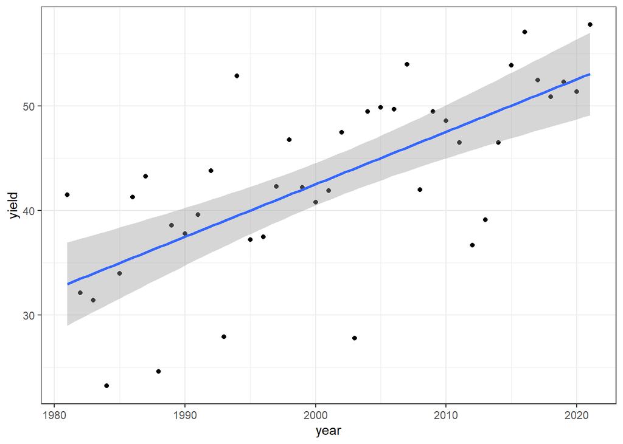

```r
madisonsoy<- soyyields %>% filter( county_name == "MADISON")

ggplot(madisonsoy, mapping = aes(x = year, y = yield)) +
  geom_point() +
  theme_bw() +
  labs(x = "year", y = "yield") +
  geom_smooth(method = lm)
```

### Bonus: Find a package to make a county map of Iowa displaying some sort of information about yields or weather. Interpret your map.

### Bonus #2: Challenge question - map trends in corn yields by county across Iowa. Interpret your map.